# DGP Dossier: synth_overlap_stressed

## 1. Identity & Status

| DGP ID | synth_overlap_stressed |
| --- | --- |
| Version | 1.6.0 |
| Status | experimental |
| Difficulty | ★★★★☆ (4/5) |
| Stress Profile | overlap: severenoise: gaussianlinearity: lineareffect: lineartarget: both |

## 2. What This DGP Stresses (Intent)

Positivity violation. The propensity is pushed toward 0/1, creating unstable inverse weights.

## 3. Identification Assumptions (Explicit)

- Selection on observables holds.
- Overlap is intentionally violated (severe).
- SUTVA holds.

## 4. Mathematical Specification

Covariates:
$$X \sim \mathcal{N}(0, I_5)$$

Propensity:
$$p(X) = \text{expit}(9 X_1 + 9 X_2)$$

The coefficient 9.0 pushes probability mass toward 0 and 1.

Outcome (control):
$$\mu_0(X) = 1 + X_1 + 0.5 X_2$$

Treatment effect:
$$\tau(X) = 1 + 0.5 X_1$$

Noise:
$$\varepsilon \sim \mathcal{N}(0, 0.5^2)$$

## 5. Oracle Truth Definition

- True ATT is computed from `structural_te` among treated units.
- True QST is computed on the oracle tau grid (`cs_get_oracle_qst()`).

## 6. Visual Diagnostics (n = 5000)

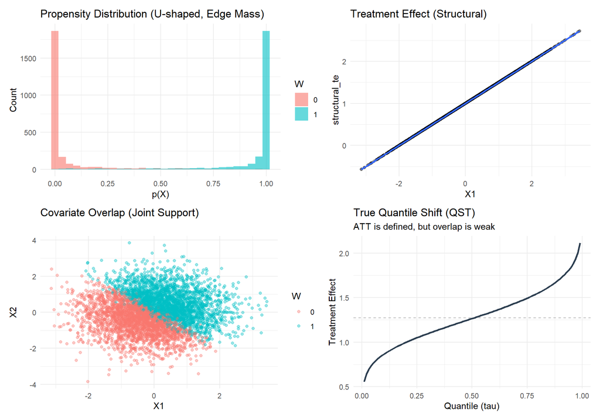

## 7. Empirical Validation

Empirical validation (n=1000, seeds=1:10)

| estimator_id | mean_bias | rmse |
| --- | --- | --- |
| ipw_att | 0.287 | 0.315 |
| oracle_att | 0.000 | 0.000 |

## 9. Implementation Reference

- Generator: `R/dgp-synth-overlap-stressed.R`
- Registry: `cs_dgp_registry()` entry for `synth_overlap_stressed`
- Oracle truth: `cs_get_oracle_qst("synth_overlap_stressed", version = "1.6.0")`

## 10. Validation Checklist

- Propensity specified as expit(9X1 + 9X2)
- X1 vs X2 titled “Covariate Overlap (Joint Support)”
- IPW benchmark failure noted

## 11. Changelog

- v1.4.0: Parameter hardening (Deprecated v1.3.0).
- v1.6.0: Implemented Common Random Numbers (CRN) for Oracle generation. Eliminates Monte Carlo noise in QST truth benchmarks.

## Appendix: Implementation

```
Source code for: dgp_synth_overlap_stressed_v160

function(n, seed = NULL, include_truth = TRUE, oracle_only = FALSE) {
  if (!is.null(seed)) {
    cs_set_rng(seed)
  }

  X1 <- stats::rnorm(n, mean = 0, sd = 1)
  X2 <- stats::rnorm(n, mean = 0, sd = 1)
  if (!isTRUE(oracle_only)) {
    X3 <- stats::rnorm(n, mean = 0, sd = 1)
    X4 <- stats::rnorm(n, mean = 0, sd = 1)
    X5 <- stats::rnorm(n, mean = 0, sd = 1)
  }

  mu0 <- 1 + X1 + 0.5 * X2
  tau <- 1 + 0.5 * X1
  p   <- stats::plogis(9.0 * X1 + 9.0 * X2)

  w <- stats::rbinom(n, size = 1L, prob = p)

  eps0 <- stats::rnorm(n, mean = 0, sd = 0.5)

  if (isTRUE(oracle_only)) {
    eps1 <- eps0
  } else {
    eps1 <- stats::rnorm(n, mean = 0, sd = 0.5)
  }

  y0 <- mu0 + eps0
  y1 <- mu0 + tau + eps1

  if (isTRUE(oracle_only)) {
    return(list(df = tibble::tibble(w = w, y0 = y0, y1 = y1)))
  }
  y  <- ifelse(w == 1L, y1, y0)

  true_att <- cs_true_att(structural_te = tau, w = w)
  true_qst <- if (isTRUE(include_truth)) {
    cs_get_oracle_qst("synth_overlap_stressed", version = "1.6.0")
```

[output cut: 19 more lines]

```
    true_qst = true_qst,
    meta = list(
      dgp_id        = "synth_overlap_stressed",
      version       = "1.6.0",
      type          = "synthetic",
      params        = list(n = n, seed = seed),
      structural_te = tau
    )
  )

  cs_check_dgp_synthetic(out)
  out
}
<bytecode: 0x000001d557c803f0>
<environment: namespace:CausalStress>
```